# SKMEL5 subclone BRAFi timecourse analysis

Darren R. Tyson

January 16, 2022

### This file used code from several other files as reference, including:

1. ion_channel_initial_list.Rmd from Philip Stauffer
2. DESeq2_subclones_timeCourse.Rmd from Corey Hayford

### Summary

This is a pipeline for differential analysis of RNASeq data from SKMEL5 sublines using DESeq2 statistical package. Three sublines: SC01 (*regressing*), SC07 (*stationary*) and SC10 (*expanding*) were analyzed for gene expression differences. In addition, time course changes in 8uM PLX4720 were also performed for each subline. Time points are: 0, 3d, 8d. The differential analysis will be performed based on the contrasts defined below. General steps for the analysis are:

###1. Read counts table: + Could be read directly as a csv/txt file. + Alignment and read counts could be done within R environment to create read counts table. 1. Define working directory, load the required libraries. 2. Get read counts table. Read the raw counts file processed by featureCounts. The fastq files were aligned with HiSat2, and the read counts were obtained using featureCounts of Rsubread packages.

```r
library(reshape2)
library(ggplot2)
library(plyr)
library(gplots)
library(Rmisc)
library(biomaRt)

# This file found at https://github.com/RyanHope/Rmisc/blob/master/R/summarySE.R
# source("summarySE.R")

SAVEPLOT  <- FALSE
OVERWRITE <- FALSE
```

### Assembling data to include gene HGNC symbols as names

This only needs to be run once to generate the proper data matrix for further analysis.

```r
ensembl <- useMart( biomart="ensembl",
                    dataset="hsapiens_gene_ensembl",
                    host="https://useast.ensembl.org")
mart <- useDataset("hsapiens_gene_ensembl", mart= ensembl, verbose= FALSE)

d <- read.csv("../data/featureCounts_matrix_all.csv", header=T, sep=',')

#Rename columns
cols <- c("ensembl_gene_id", "SC01_day0_rep1", "SC01_day0_rep2", "SC01_day0_rep3",
          "SC01_day3_rep1", "SC01_day3_rep2", "SC01_day3_rep3",
          "SC01_day8_rep1", "SC01_day8_rep2", "SC01_day8_rep3",
          "SC07_day0_rep1", "SC07_day0_rep2", "SC07_day0_rep3",
          "SC07_day3_rep1", "SC07_day3_rep2", "SC07_day3_rep3",
          "SC07_day8_rep1", "SC07_day8_rep2", "SC07_day8_rep3",
          "SC10_day0_rep1", "SC10_day0_rep2", "SC10_day0_rep3",
          "SC10_day3_rep1", "SC10_day3_rep2", "SC10_day3_rep3",
          "SC10_day8_rep1", "SC10_day8_rep2", "SC10_day8_rep3")
names(d) <- cols
ensembl_gene_id <- d$ensembl_gene_id
gene_list <- getBM(attributes= c("ensembl_gene_id", "hgnc_symbol"),
                filters="ensembl_gene_id",
                values=ensembl_gene_id,
                mart=mart)

d <- merge(d, gene_list, by="ensembl_gene_id")

# remove ensembl gene IDs
d <- d[, -1]

# make rownames from HGNC gene names
rownames(d) <- make.names(d$hgnc_symbol, unique = T)

# remove hgnc_symbol
d$hgnc_symbol <- NULL

# remove genes with <5 counts in all samples
d <- d[apply(d, 1, function(x) all(x > 5)),]

# write the data to a new file
fn <- "../data/SKMEL5_subclone_BRAFi_timecourse_RNAseq_data.csv"
if(!file.exists(fn) | OVERWRITE) write.csv(d, fn)
```

### Load data

```r
d <- read.csv("../data/SKMEL5_subclone_BRAFi_timecourse_RNAseq_data.csv", row.names=1)
```

### Convert data to ExpressionSet

This will allow better annotations of samples and genes. First, prepare reusable sample information. This can also be used outside of expressionSet.

```r
sample_info <- as.data.frame(do.call(rbind, strsplit(colnames(d), "_")))
colnames(sample_info) <- c("subclone", "time_days", "rep")
rownames(sample_info) <- colnames(d)

sample_info$time_days <- as.integer(gsub("day","",sample_info$time_days))
sample_info$rep <- as.integer(gsub("rep","",sample_info$rep))
sample_info$uid <- paste(sample_info$subclone, sample_info$time_days, sep="_")
head(sample_info)
```

|  | subclone | time_days | rep | uid |
| --- | --- | --- | --- | --- |
| SC01_day0_rep1 | SC01 | 0 | 1 | SC01_0 |
| SC01_day0_rep2 | SC01 | 0 | 2 | SC01_0 |
| SC01_day0_rep3 | SC01 | 0 | 3 | SC01_0 |
| SC01_day3_rep1 | SC01 | 3 | 1 | SC01_3 |
| SC01_day3_rep2 | SC01 | 3 | 2 | SC01_3 |
| SC01_day3_rep3 | SC01 | 3 | 3 | SC01_3 |

```r
SUBCLONES <- unique(sapply(strsplit(colnames(d), "_"), "[[", 1))
ALLGENES <- sort(unique(rownames(d)))

gene_sets <- list(Kv7=c("KCNQ1", "KCNQ2" , "KCNQ3", "KCNQ4" , "KCNQ5"),
                  musc=c("CHRM1", "CHRM2", "CHRM3", "CHRM4", "CHRM5"),
                  gaba=c("GABRG1", "GABRG2", "GABGRD"),
                  Glut=c("GRID2", "GRIN2B" , "GRIN1"),
                  TRP=c("TRPM6", "TRPV6", "TRPC7" , "TRPC3"),
                  NaKATPase=c("ATP1A3" , "ATP1A4" , "ATP1B1" , "ATP1B2", "ATP2A3"),
                  RYR= c("RYR1" , "RYR2" , "RYR3"),
                  serca= c("ATP2A1" , "ATP2A2" , "ATP2A3"),
                  PMCA= c("ATP2B1" , "ATP2B2" , "ATP2B3" , "ATP2B4"),
                  orai= c("ORAI1" , "ORAI2" , "ORAI3"),
                  stim= c("STIM1","STIM2"),
                  VGCC=c(rownames(d)[grep("CACNA1",rownames(d))],"CACNA2D2")
                  )
```

### Descriptions of gene classes

#### Classes

- *PMCA*: Plasma membrane calcium ATPases; Ca++ pumps to EC space
- *orai*:
- *stim*:
- *VGCC*: voltage-gated calcium channel
- *TRP*: transient receptor potential cation channel family

### Functions to summarize data (average across replicates) and plot

```r
summarize_dat <- function(...) summarySE(..., measurevar = "value",
                                         groupvars = c("subclone", "time_days", "variable"))

prep_dat <- function(x=d, gene_name, log_scale=TRUE)
{
    genes <- gene_name[gene_name %in% rownames(x)]
    dat <- t(x[genes,])
    if(log_scale) dat <- log2(dat+1)
    dtp <- cbind(sample_info, dat)
    z <- melt(data = dtp, id.vars = c("subclone", "time_days"), measure.vars = genes)
    z <- summarize_dat(data=z)
    colnames(z)[colnames(z)=="variable"] <- "gene"
    return(z)
}

plot_timecourse <- function(dtp, plot_title="Gene expression timecourse", savefilename=NULL)
{
    genes <- unique(dtp$gene)
    myplot <- ggplot(dtp, aes(x=time_days, y=value, group = interaction(gene, subclone))) +
        geom_line(linewidth=1, aes(color = subclone, linetype = gene)) +
        geom_point(size = 1.5, aes(color = subclone)) +
        geom_errorbar(aes(ymin=value-sd, ymax=value+sd, color = subclone), width=.2, size=1.5) +
        theme_bw() + xlab("Time (days)") + ylab("Transcript count") +
        ggtitle(plot_title) +
        theme(legend.text = element_text(size = 10), legend.position = "right",
              plot.title = element_text(size = 14, hjust = 0.5, face = "bold"),
              axis.text=element_text(size=12),
              legend.title = element_text(size=12,face="bold"),
              axis.title=element_text(size=12,face="bold"))
    if(!is.null(savefilename)) ggsave(savefilename, width = 6, height = 4)
    return(myplot)
}
```

### Neural potassium channels

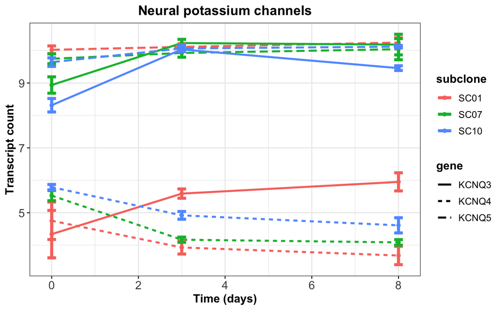

```r
savefilename <- if(SAVEPLOT) { "Neural_potassium_channels.pdf" } else { NULL }
plot_timecourse(prep_dat(gene_name=gene_sets[["Kv7"]], log_scale=TRUE),
                plot_title="Neural potassium channels",
                savefilename=savefilename)
```

### Voltage-gated calcium channels

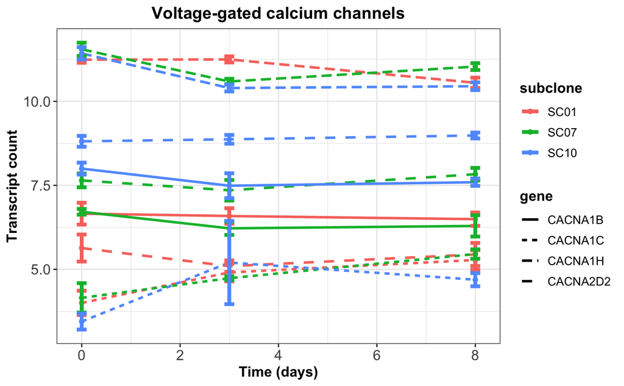

```r
savefilename <- if(SAVEPLOT) { "Voltage-gated_calcium_channels.pdf" } else { NULL }
plot_timecourse(prep_dat(gene_name=gene_sets[["VGCC"]]),
                plot_title="Voltage-gated calcium channels",
                savefilename=savefilename)
```

### IP3 receptors

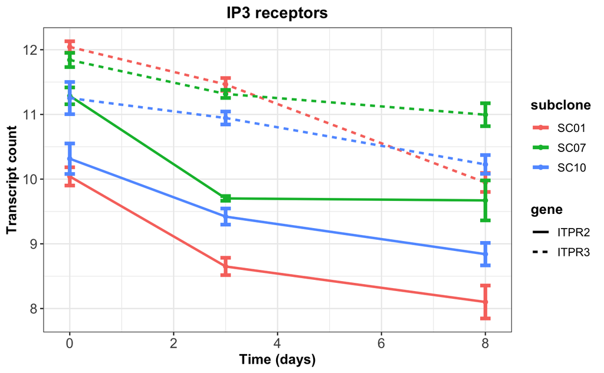

```r
savefilename <- if(SAVEPLOT) { "IP3_receptors.pdf" } else { NULL }
plot_timecourse(prep_dat(gene_name=c("ITPR2","ITPR3"), log_scale=TRUE),
                plot_title="IP3 receptors",
                savefilename=savefilename)
```

### My gene set based on differential expression and role in calcium signaling

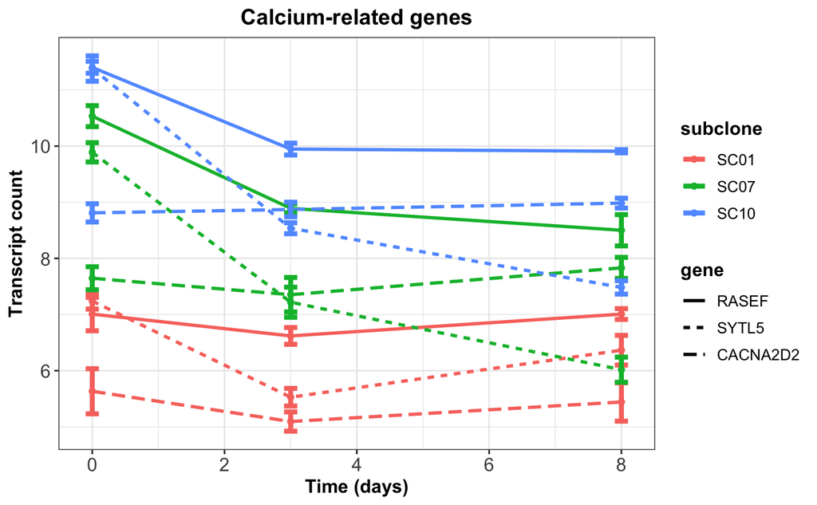

```r
calc_genes <- c("ATP2B2","RASEF","SYTL5","CACNA2D2")

savefilename <- if(SAVEPLOT) { "Calcium_related_genes.pdf" } else { NULL }
plot_timecourse(prep_dat(gene_name=calc_genes, log_scale=TRUE),
                plot_title="Calcium-related genes",
                savefilename=savefilename)
```

### NFAT genes

Calcium-dependent transcription factors (regulated by calcineurin).

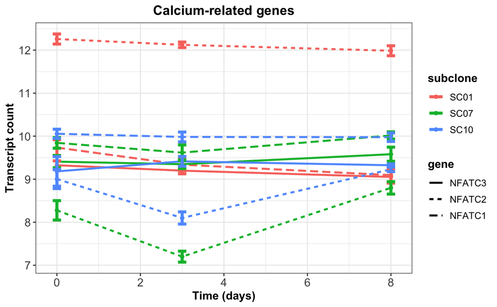

```r
other_genes <- c(rownames(d)[grep("NFATC[1-4]$",rownames(d))])

savefilename <- if(SAVEPLOT) { "Calcium_related_genes.pdf" } else { NULL }
plot_timecourse(prep_dat(gene_name=other_genes, log_scale=TRUE),
                plot_title="Calcium-related genes",
                savefilename=savefilename)
```

MCOLN1 = TRPML1 gene

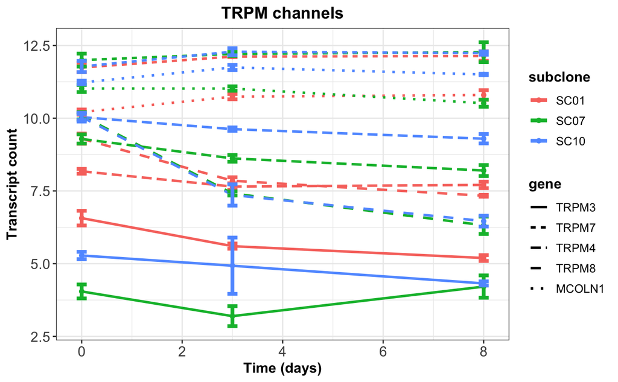

```r
trpm348l1 <- c(rownames(d)[grep("^TRPM[3478]",rownames(d))],"MCOLN1")

savefilename <- if(SAVEPLOT) { "TRPM_channels.pdf" } else { NULL }
plot_timecourse(prep_dat(gene_name=trpm348l1, log_scale=TRUE),
                plot_title="TRPM channels",
                savefilename=savefilename)
```

Reduction of TRPM4 (~2-fold) and TRPM8 (~8-fold) expression in idling

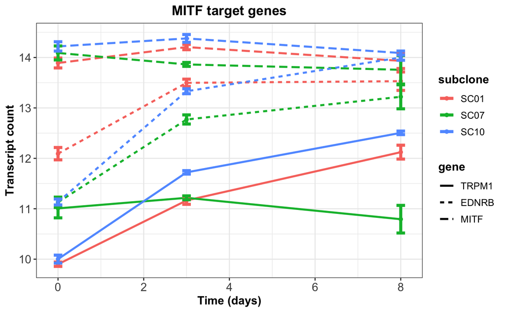

```r
mitf_targets <- c("TRPM1","EDNRB","MITF")
savefilename <- if(SAVEPLOT) { "MITF_targets.pdf" } else { NULL }
plot_timecourse(prep_dat(gene_name=mitf_targets, log_scale=TRUE),
                plot_title="MITF target genes",
                savefilename=savefilename)
```

Related to this paper: Tasdogan, A., Faubert, B., Ramesh, V., Ubellacker, J. M., Shen, B., Solmonson, A., Murphy, M. M., Gu, Z., Gu, W., Martin, M., Kasitinon, S. Y., Vandergriff, T., Mathews, T. P., Zhao, Z., Schadendorf, D., DeBerardinis, R. J., & Morrison, S. J. (2020). Metabolic heterogeneity confers differences in melanoma metastatic potential. Nature, 577(7788), 115-120. https://doi.org/10.1038/s41586-019-1847-2

MCT1, MCT2, and MCT4 genes for transporting lactate.

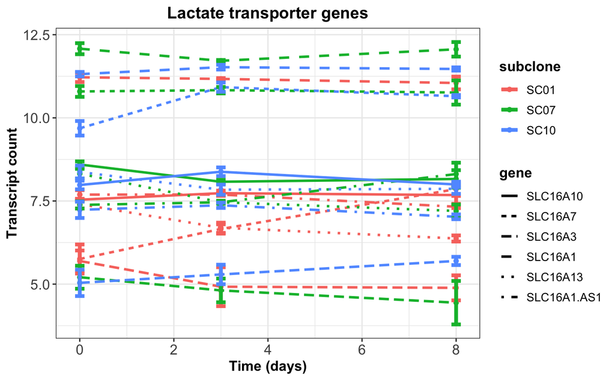

```r
slc16a_transporters <- c(rownames(d)[grep("^SLC16A[137]",rownames(d))])
savefilename <- if(SAVEPLOT) { "SLC16A_transporters.pdf" } else { NULL }
plot_timecourse(prep_dat(gene_name=slc16a_transporters, log_scale=TRUE),
                plot_title="Lactate transporter genes",
                savefilename=savefilename)
```

The effects of BRAFi on gene expression appear minimal.

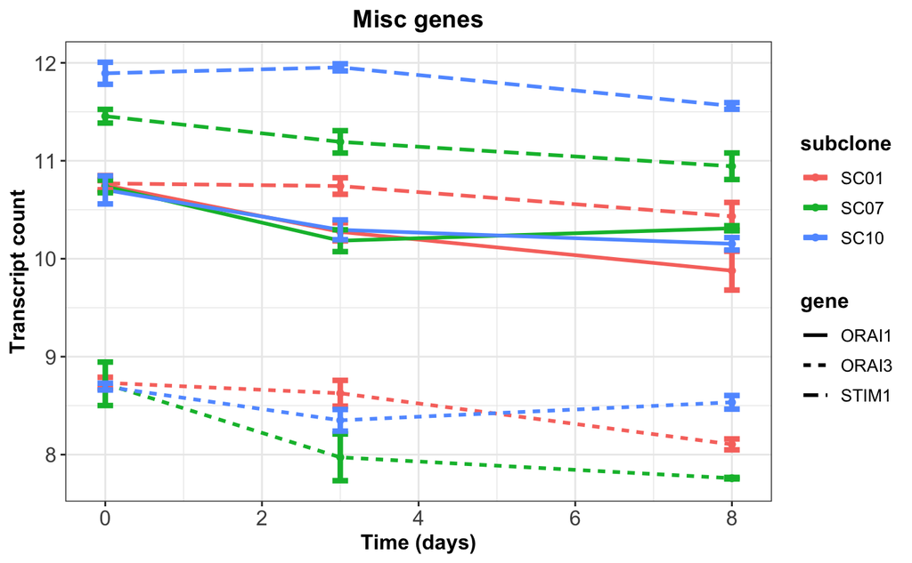

```r
temp <- c("ORAI1","ORAI3","STIM1")
# temp <- c("ATP2B4")

savefilename <- if(SAVEPLOT) { "temp_genes.pdf" } else { NULL }
plot_timecourse(prep_dat(gene_name=temp, log_scale=TRUE),
                plot_title="Misc genes",
                savefilename=savefilename)
```

### Assemble data of most important gene expression changes

Relevant refs: Hegedũs, L., Garay, T., Molnár, E., Varga, K., Bilecz, Á., Török, S., Padányi, R., Pászty, K., Wolf, M., Grusch, M., Kállay, E., Döme, B., Berger, W., Hegedũs, B., & Enyedi, A. (2017). The plasma membrane Ca<sup>2+</sup> pump PMCA4b inhibits the migratory and metastatic activity of BRAF mutant melanoma cells. Int J Cancer, 140(12), 2758-2770. https://doi.org/10.1002/ijc.30503  
Gene is ATP2B4

Genes to include:

1. IP3 receptors: *ITPR2*, *ITPR3*
2. voltage-gated calcium channel: *CACNA1H*
3. Plasma membrane calcium pump: *ATP2B4*, aka PMCA4b
4. calcium channel: *TRPM8* (MITF reporter), high levels inhibit prolif in PCa; *TRPM1* aka melanostatin, melanoma metastasis suppressor gene (note miR-211 is controlled by the same promoter; both are MITF target genes)
5. PPARgamma: *PPARGC1A*
6. ER-regulated calcium channels: *ORAI1*, *ORAI3*, *STIM1*
7. Other melanocytic differentiation genes: *MLANA*, *TYR*, *TYRP1*
8. Drug resistance-associated genes: *AXL*, *NTRK1*, *CDH2*, *TNFRSF1A*
9. MAPK-responsive genes: *POU3F2*

https://doi.org/10.1158/0008-5472.can-08-1053  
The Brn-2 transcription factor (POU3F2) regulates proliferation and invasiveness and lies downstream from mitogen-activated protein kinase (MAPK) and Wnt/β-catenin, two melanoma-associated signaling pathways

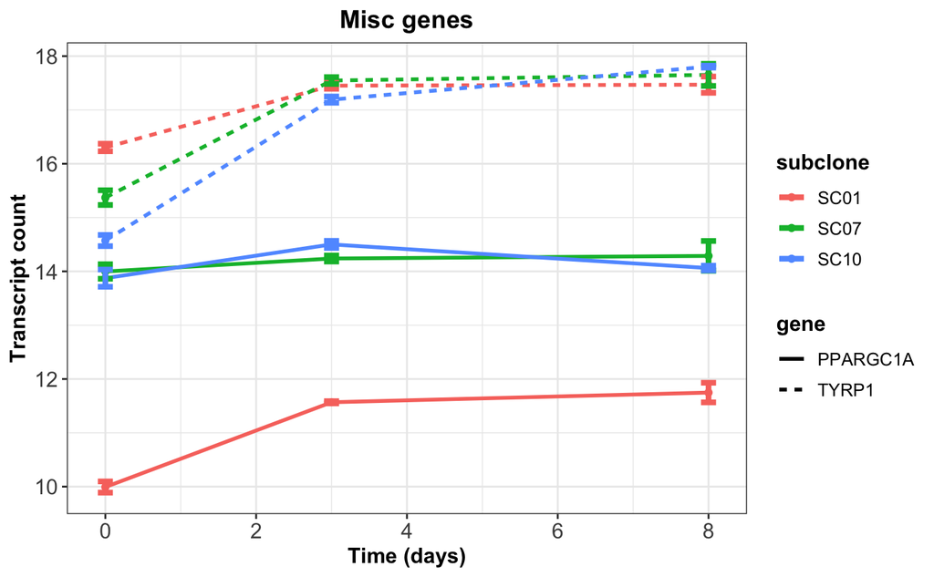

```r
temp <- c("PPARGC1A","TYRP1")
# temp <- c("AXL","NGFR","CDH2","TNFRSF1A")

# minimally or unchanged: ,"MLANA","TYR","NGFR","PAX3"
# not present: "TYRP2","MART1","SOX10"
# somewhat downregulated: "TBX2","MC1R"

savefilename <- if(SAVEPLOT) { "temp_genes.pdf" } else { NULL }
plot_timecourse(prep_dat(gene_name=temp, log_scale=TRUE),
                plot_title="Misc genes",
                savefilename=savefilename)
```

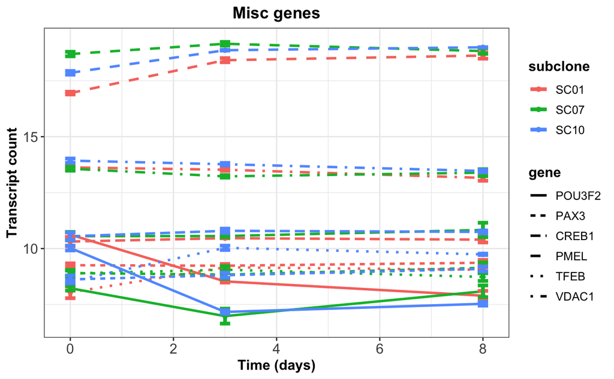

```r
temp <- c("POU3F2","SOX10","PAX3","CREB1","PMEL","TFEB","VDAC1")

savefilename <- if(SAVEPLOT) { "temp_genes.pdf" } else { NULL }
plot_timecourse(prep_dat(gene_name=temp, log_scale=TRUE),
                plot_title="Misc genes",
                savefilename=savefilename)
```

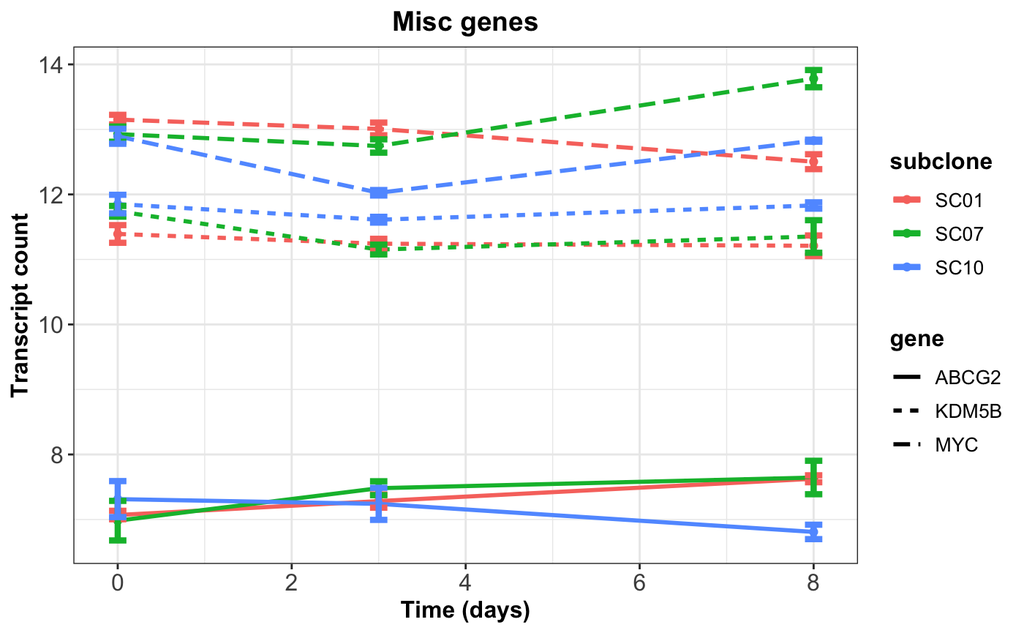

```r
temp <- c("CASR","ABCB1","ABCG2","KDM5B","MYC")

savefilename <- if(SAVEPLOT) { "temp_genes.pdf" } else { NULL }
plot_timecourse(prep_dat(gene_name=temp, log_scale=TRUE),
                plot_title="Misc genes",
                savefilename=savefilename)
```

Calcium homeostasis genes http://purl.obolibrary.org/obo/GO_0006874 GO:0051480

```r
ensembl <- useMart( biomart="ensembl",
                    dataset="hsapiens_gene_ensembl",
                    host="https://useast.ensembl.org")
mart <- useDataset("hsapiens_gene_ensembl", mart= ensembl, verbose= FALSE)

m <- getBM(attributes = c('ensembl_gene_id','external_gene_name', 'hgnc_symbol','name_1006'),
      filters = 'go',
      values = 'GO:0006874',
      mart = ensembl)
```

### Extract gene names into `ca_sig` object

Filter for gene names in data. Keep track of which ones weren’t present.

```r
ca_sig <- unique(m$hgnc_symbol)
missing_genes <- ca_sig[!ca_sig %in% ALLGENES]
ca_sig <- ca_sig[ca_sig %in% ALLGENES]

message("Genes in signature missing from data:")
```

```
Genes in signature missing from data:
```

```r
print(missing_genes)
```

```
 [1] "GPR12"   "HTR2A"   "STC1"    "EDN3"    "DRD5"    "EDN1"    "CCL3"    "TRPA1"   "CALCB"   "CCL23"   "CCL15"   "CCL5"
[13] "CCL14"   "CSRP3"   "SLC24A3" "ELANE"   "PLN"     "EDNRA"   "SLC24A4" "GCM2"    "SPPL2C"  "CCL19"   "ATP13A4" "CD40"
[25] "ATP2C2"  "RGN"     "PTH1R"   "TRPV4"   "KEL"     "SLC24A2" "HTR2C"   "NPPC"    "HTR2B"   "DHRS7C"  "UMOD"    "STC2"
[37] "SLC8A3"  "CXCL12"  "CCR1"    "CCR2"    "RYR1"    "CCL7"    "CCL11"   "CCL8"    "CCL13"   "CCL1"    "ATP13A5" "TRDN"
[49] "CDH5"    "CTRC"    "CASR"    "DRD3"    "PTH"     "TNNI3"   "CALCA"   "EDN2"    "DRD2"    "SLC8A1"
```

### Other calcium-relevant genes

```r
to_add <- c(rownames(d)[grep("^TRPM",rownames(d))],"MCOLN1")
to_add <- append(to_add, rownames(d)[grep("^ITPR[1-3]$",rownames(d))])
to_add <- append(to_add, rownames(d)[grep("^ORAI",rownames(d))])
ca_sig <- unique(union(ca_sig,to_add))
```

```r
ca_dat <- as.matrix(d[rownames(d) %in% ca_sig,])
ca_dat <- data.frame(gene_name=rep(ca_sig),gene_count=as.integer(ca_dat))
ca_dat$sample <- rep(colnames(d), each=length(ca_sig))
temp <- cbind(ca_dat, sample_info[ca_dat$sample,c("subclone","time_days","rep")])
temp$uid <- paste(temp$subclone, temp$time_days, temp$gene_name, sep="_")
temp <- temp[order(temp$uid,temp$rep),]
rownames(temp) <- NULL
temp$l2 <- log2(temp$gene_count+1)

a <- aggregate(l2 ~ uid, data=temp, FUN=mean)
a$subclone <- sapply(strsplit(a$uid,"_"), "[[", 1)
a$day <- as.integer(sapply(strsplit(a$uid,"_"), "[[", 2))
a$gene <- sapply(strsplit(a$uid, "_"), "[[", 3)
a$sc_gene <- paste(a$subclone, a$gene, sep="_")
a <- a[order(a$gene,a$subclone,a$day),]
a$change <- NA
for(x in unique(a$sc_gene))
    a[a$sc_gene==x,"change"] <- a[a$sc_gene==x,"l2"] - a[a$sc_gene==x,"l2"][1]

# remove day 0 (reference)
# b <- a[a$day!=0,]

# b <- as.data.frame(t(matrix(b$change, nrow=6)))
# colnames(b) <- apply(a[a$day!=0,][1:6,c("subclone","day")], 1, function(x) paste(x,collapse="_"))
b <- as.data.frame(t(matrix(a$change, nrow=9)))
colnames(b) <- apply(a[1:9,c("subclone","day")], 1, function(x) paste(x,collapse="_"))
rownames(b) <- unique(a$gene)
b <- b[order(apply(b, 1, function(x) max(x)), decreasing = TRUE), ]
```

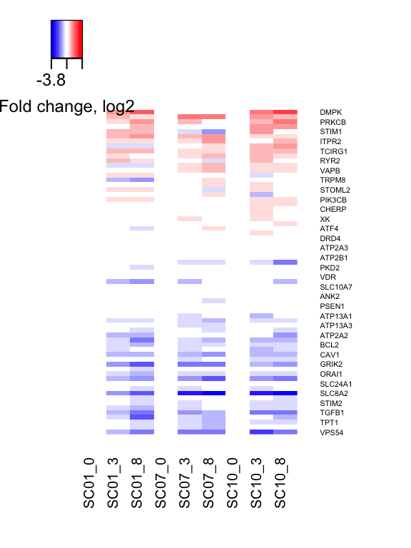

```r
if(SAVEPLOT)
    pdf(file="~/Desktop/ca-genes_fold-change_heatmap.pdf", height=6, width=4)
heatmap.2(as.matrix(b), Rowv=FALSE, Colv=FALSE, dendrogram="none",
          scale = "none", cexRow=0.4, cexCol=0.75, trace = "none",
          col=bluered(20), key.title=NA, key.xlab="Fold change, log2", key.ylab=NA,
          density.info = "none",
          keysize = 1,
          key.par=list(mgp=c(1.5, 0.5, 0), mar=c(2.5, 2.5, 1, 0)),
          key.xtickfun=function() {
                 breaks <- parent.frame()$breaks
                 return(list(
                      at=parent.frame()$scale01(c(breaks[1], 0,
                                                  breaks[length(breaks)])),
                      labels=c(as.character(signif(breaks[1],2)), "0",
                               as.character(signif(breaks[length(breaks)],2)))
                 ))}
          )
```

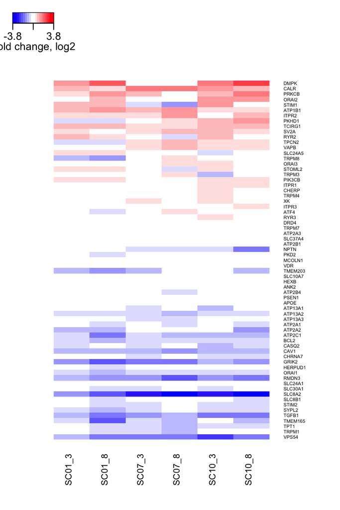

```r
if(SAVEPLOT)
    pdf(file="~/Desktop/ca-genes_fold-change_heatmap.pdf", height=6, width=4)
heatmap.2(as.matrix(b[,!grepl("_0",colnames(b))]), Rowv=FALSE, Colv=FALSE, dendrogram="none",
          scale = "none", cexRow=0.4, cexCol=0.75, trace = "none",
          col=bluered(20), key.title=NA, key.xlab="Fold change, log2", key.ylab=NA,
          density.info = "none",
          keysize = 0.75,
          key.par=list(mgp=c(1, 0.5, 0), mar=c(4.5, 1, 1, 0)),
          key.xtickfun=function() {
                 breaks <- parent.frame()$breaks
                 return(list(
                      at=parent.frame()$scale01(c(breaks[1], 0,
                                                  breaks[length(breaks)])),
                      labels=c(as.character(signif(breaks[1],2)), "0",
                               as.character(signif(breaks[length(breaks)],2)))
                 ))}
          )
```

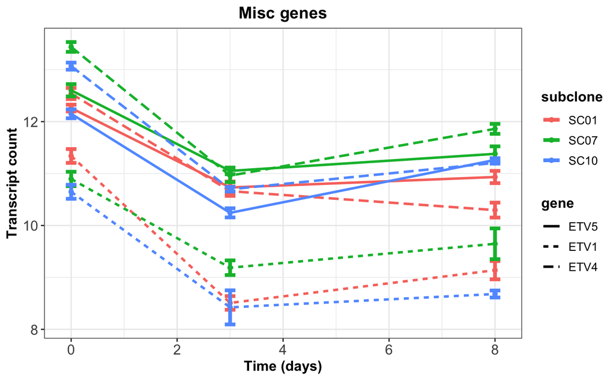

```r
# temp <- c("MITF","TFEB","TFE3)
temp <- c("ETV5","ETV1","ETV4")

savefilename <- if(SAVEPLOT) { "temp_genes.pdf" } else { NULL }
plot_timecourse(prep_dat(gene_name=temp, log_scale=TRUE),
                plot_title="Misc genes",
                savefilename=savefilename)
```

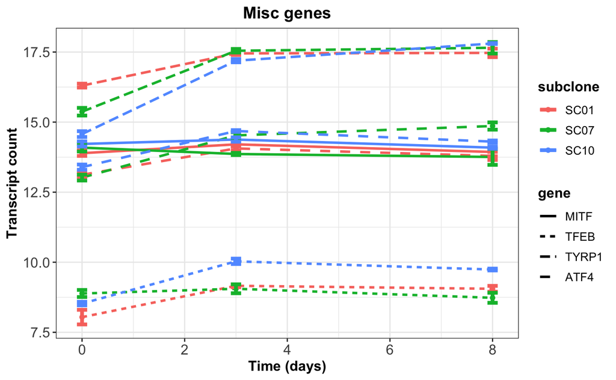

```r
temp <- c("MITF","TFEB","TYRP1","ATF4")
# temp <- c("ETV5","ETV1","ETV4")

savefilename <- if(SAVEPLOT) { "temp_genes.pdf" } else { NULL }
plot_timecourse(prep_dat(gene_name=temp, log_scale=TRUE),
                plot_title="Misc genes",
                savefilename=savefilename)
```

### Preparation of data for heatmaps of ANY gene set

```r
GENE_LIST <- c("MITF","TFEB","ETV1","ETV4","ETV5","POU3F2","SLC24A5") # add all relevant genes to this object
```

```r
refmtData <- function(dat=d, genes=GENE_LIST)
{
    avail_genes <- genes[genes %in% rownames(dat)]
    new_dat <- as.matrix(dat[avail_genes,])
    new_dat <- data.frame(gene_name=rep(avail_genes),gene_count=as.integer(new_dat))
    new_dat$sample <- rep(colnames(dat), each=length(avail_genes))

    temp <- cbind(new_dat, sample_info[new_dat$sample,c("subclone","time_days","rep")])
    temp$uid <- paste(temp$subclone, temp$time_days, temp$gene_name, sep="_")
    temp <- temp[order(temp$uid,temp$rep),]
    rownames(temp) <- NULL
    temp$l2 <- log2(temp$gene_count+1)

    a <- aggregate(l2 ~ uid, data=temp, FUN=mean)
    a$subclone <- sapply(strsplit(a$uid,"_"), "[[", 1)
    a$day <- as.integer(sapply(strsplit(a$uid,"_"), "[[", 2))
    a$gene <- sapply(strsplit(a$uid, "_"), "[[", 3)
    a$sc_gene <- paste(a$subclone, a$gene, sep="_")
    a <- a[order(a$gene,a$subclone,a$day),]
    a$change <- NA
    for(x in unique(a$sc_gene))
        a[a$sc_gene==x,"change"] <- a[a$sc_gene==x,"l2"] - a[a$sc_gene==x,"l2"][1]

    my_ncol <- ncol(dat)/max(temp$rep)
    b <- as.data.frame(t(matrix(a$change, nrow=my_ncol)))
    colnames(b) <- apply(a[seq(my_ncol),c("subclone","day")], 1, function(x) paste(x,collapse="_"))
    rownames(b) <- unique(a$gene)
    b <- b[order(apply(b, 1, function(x) max(x)), decreasing = TRUE), ]
    return(b)
}
```

```r
z <- refmtData(genes=ALLGENES)
if(SAVEFILES) write.csv(z, "~/Desktop/SKMEL5_subclone_BRAFi_l2FC_d3and8.csv")
```

```r
mygenes <- c(rownames(d)[grep("TRPM",rownames(d))],
             rownames(d)[grep("^ITPR[2-3]$",rownames(d))],
             rownames(d)[grep("^RYR",rownames(d))],
             rownames(d)[grep("^ORAI",rownames(d))],
             rownames(d)[grep("^STIM[12]",rownames(d))],
             "ATP2B4","PPARGC1A","TYR","TYRP1","DCT","MLANA","TPCN2",
             "MITF","TFEB","TFE3","TFEC",
             rownames(d)[grep("^CACNA1",rownames(d))]
             )

z <- refmtData(genes=mygenes)
```

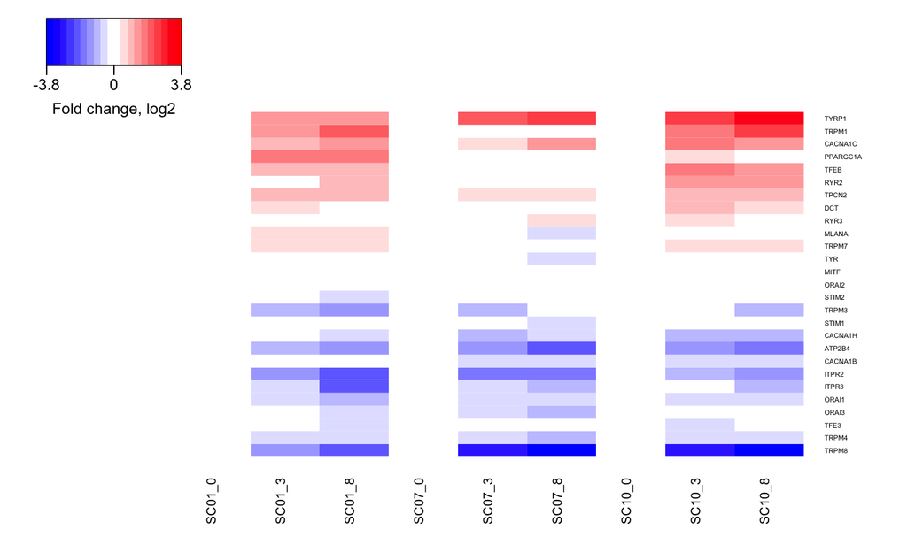

```r
if(SAVEPLOT)
    pdf(file="~/Desktop/mygenes_fold-change_heatmap.pdf", height=3, width=5)

heatmap.2(as.matrix(z), Rowv=FALSE, Colv=FALSE, dendrogram="none",
          scale = "none", cexRow=0.4, cexCol=0.75, trace = "none",
          col=bluered(20), key.title=NA, key.xlab="Fold change, log2", key.ylab=NA,
          density.info = "none",
          keysize = 1,
          key.par=list(mgp=c(1.5, 0.5, 0), mar=c(2.5, 2.5, 1, 0)),
          key.xtickfun=function() {
                 breaks <- parent.frame()$breaks
                 return(list(
                      at=parent.frame()$scale01(c(breaks[1], 0,
                                                  breaks[length(breaks)])),
                      labels=c(as.character(signif(breaks[1],2)), "0",
                               as.character(signif(breaks[length(breaks)],2)))
                 ))}
          )
```

Drop 0 time point columns and replot

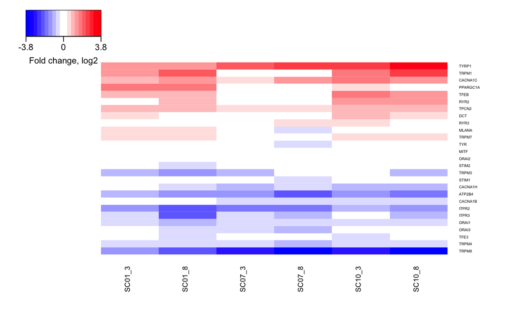

```r
z <- z[,!grepl("_0",colnames(z))]

if(SAVEPLOT)
    pdf(file="~/Desktop/mygenes_fold-change_heatmap.pdf", height=3, width=5)

heatmap.2(as.matrix(z), Rowv=FALSE, Colv=FALSE, dendrogram="none",
          scale = "none", cexRow=0.4, cexCol=0.75, trace = "none",
          col=bluered(20), key.title=NA, key.xlab="Fold change, log2", key.ylab=NA,
          density.info = "none",
          keysize = 1,
          key.par=list(mgp=c(1.5, 0.5, 0), mar=c(2.5, 2.5, 1, 0)),
          key.xtickfun=function() {
                 breaks <- parent.frame()$breaks
                 return(list(
                      at=parent.frame()$scale01(c(breaks[1], 0,
                                                  breaks[length(breaks)])),
                      labels=c(as.character(signif(breaks[1],2)), "0",
                               as.character(signif(breaks[length(breaks)],2)))
                 ))}
          )
```